# tp_imp_mult

On observe qu’il y à 23 observations avec 0 donnéess manquantes, 3 avec 1 pour lenghts, 1 avec 1 pour face_breath, 2 avec 1 pourface_height, 1 avec 1 pour type, 1 avec 1 pour height et 1 avec 2 pour breadth et face_breadth

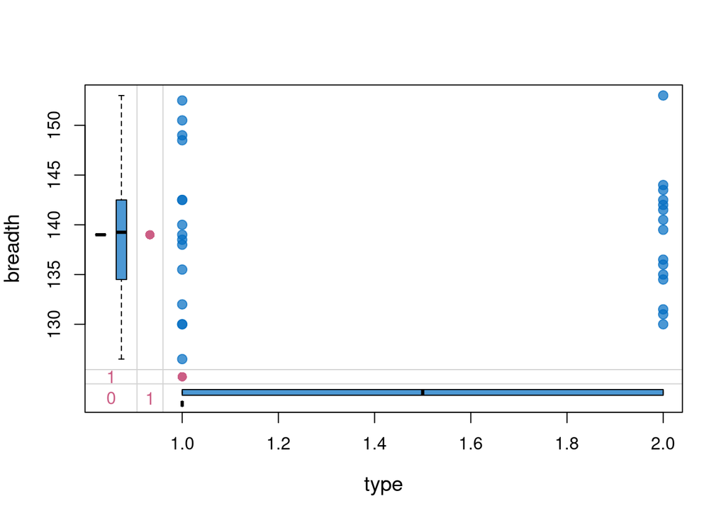

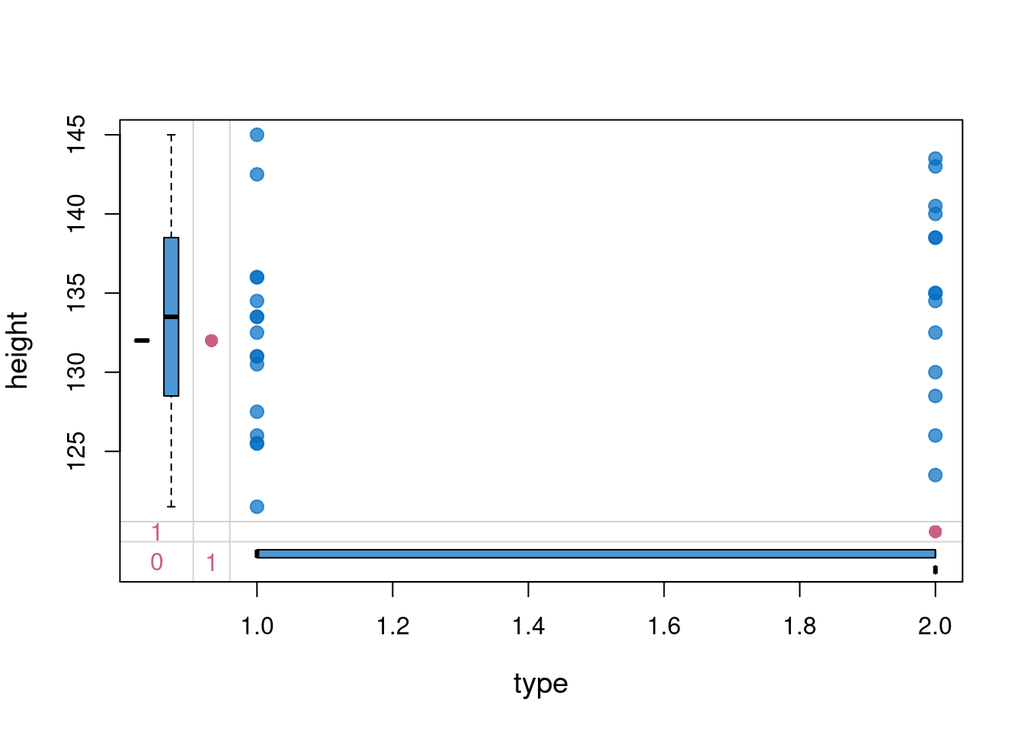

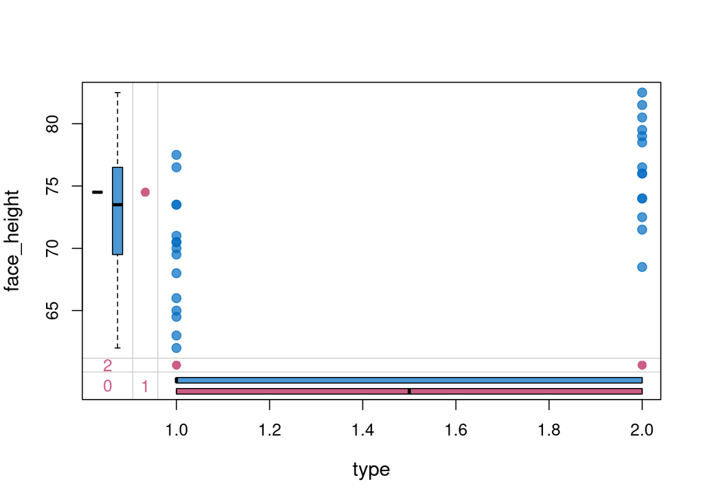

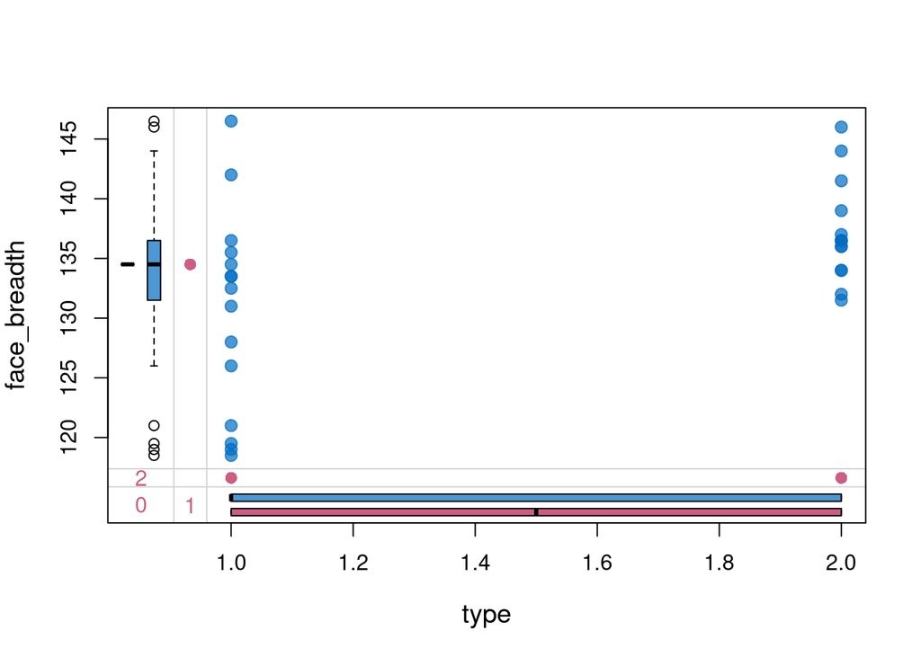

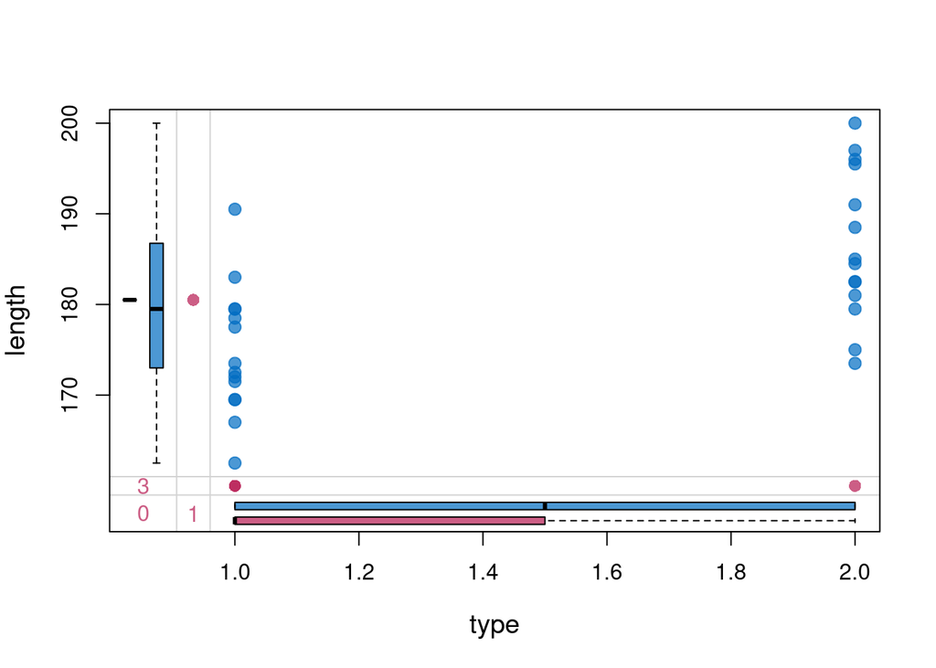

boxplot assez proche (pour une valeur manquante) on peut utiliser MICE

## Imputation des données manquantes

## Regression logistique

### On complete Donnéess manquantes avec MICE:

```
## Class: mids
## Number of multiple imputations:  5
## Imputation methods:
##       length      breadth       height  face_height face_breadth         type
##        "pmm"        "pmm"        "pmm"        "pmm"        "pmm"     "logreg"
## PredictorMatrix:
##              length breadth height face_height face_breadth type
## length            0       1      1           1            1    1
## breadth           1       0      1           1            1    1
## height            1       1      0           1            1    1
## face_height       1       1      1           0            1    1
## face_breadth      1       1      1           1            0    1
## type              1       1      1           1            1    0
```

La méthode pmm est utilisé pour imputer les différentes variables en se basant sur la moyenne prédite

On peut observer les données imputées:

```
## $length
##        1     2     3     4     5
## 5  196.0 173.5 191.0 169.5 180.5
## 17 162.5 173.5 172.5 173.5 162.5
## 29 180.5 175.0 191.0 182.5 183.0
##
## $breadth
##        1   2     3     4     5
## 11 131.5 142 142.5 141.5 142.5
##
## $height
##        1     2     3   4     5
## 22 127.5 133.5 140.5 135 140.5
##
## $face_height
##       1    2    3    4  5
## 6  70.5 77.5 74.5 73.5 65
## 21 76.0 81.5 68.5 79.0 76
##
## $face_breadth
##        1     2     3   4   5
## 11 119.5 146.5 135.5 131 128
## 25 136.5 141.5 144.0 134 146
##
## $type
##    1 2 3 4 5
## 13 B B B B B
```

```
##      length         breadth          height       face_height
##  Min.   :162.5   Min.   :126.5   Min.   :121.5   Min.   :62.00
##  1st Qu.:173.2   1st Qu.:133.9   1st Qu.:128.2   1st Qu.:69.88
##  Median :180.0   Median :139.0   Median :133.0   Median :73.50
##  Mean   :180.5   Mean   :139.0   Mean   :133.1   Mean   :72.89
##  3rd Qu.:185.9   3rd Qu.:142.5   3rd Qu.:136.6   3rd Qu.:76.50
##  Max.   :200.0   Max.   :153.0   Max.   :145.0   Max.   :82.50
##   face_breadth   type
##  Min.   :118.5   A:16
##  1st Qu.:131.4   B:16
##  Median :134.5
##  Mean   :133.4
##  3rd Qu.:136.5
##  Max.   :146.5
```

```
##      length         breadth          height       face_height
##  Min.   :162.5   Min.   :126.5   Min.   :121.5   Min.   :62.00
##  1st Qu.:173.5   1st Qu.:134.9   1st Qu.:129.6   1st Qu.:69.88
##  Median :179.5   Median :139.2   Median :133.5   Median :73.75
##  Mean   :180.0   Mean   :139.3   Mean   :133.3   Mean   :73.28
##  3rd Qu.:184.6   3rd Qu.:142.5   3rd Qu.:136.6   3rd Qu.:77.50
##  Max.   :200.0   Max.   :153.0   Max.   :145.0   Max.   :82.50
##   face_breadth   type
##  Min.   :118.5   A:16
##  1st Qu.:131.9   B:16
##  Median :135.0
##  Mean   :134.4
##  3rd Qu.:137.5
##  Max.   :146.5
```

```
##      length         breadth          height       face_height
##  Min.   :162.5   Min.   :126.5   Min.   :121.5   Min.   :62.00
##  1st Qu.:173.2   1st Qu.:134.9   1st Qu.:129.6   1st Qu.:69.25
##  Median :180.0   Median :139.2   Median :133.5   Median :73.50
##  Mean   :181.0   Mean   :139.3   Mean   :133.5   Mean   :72.78
##  3rd Qu.:189.0   3rd Qu.:142.5   3rd Qu.:138.5   3rd Qu.:76.50
##  Max.   :200.0   Max.   :153.0   Max.   :145.0   Max.   :82.50
##   face_breadth   type
##  Min.   :118.5   A:16
##  1st Qu.:131.9   B:16
##  Median :135.0
##  Mean   :134.1
##  3rd Qu.:136.6
##  Max.   :146.5
```

```
##      length         breadth          height       face_height
##  Min.   :162.5   Min.   :126.5   Min.   :121.5   Min.   :62.00
##  1st Qu.:173.2   1st Qu.:134.9   1st Qu.:129.6   1st Qu.:69.88
##  Median :179.5   Median :139.2   Median :133.5   Median :73.50
##  Mean   :180.1   Mean   :139.3   Mean   :133.4   Mean   :73.08
##  3rd Qu.:184.6   3rd Qu.:142.5   3rd Qu.:136.6   3rd Qu.:76.75
##  Max.   :200.0   Max.   :153.0   Max.   :145.0   Max.   :82.50
##   face_breadth   type
##  Min.   :118.5   A:16
##  1st Qu.:131.4   B:16
##  Median :134.2
##  Mean   :133.7
##  3rd Qu.:136.5
##  Max.   :146.5
```

```
##      length         breadth          height       face_height
##  Min.   :162.5   Min.   :126.5   Min.   :121.5   Min.   :62.00
##  1st Qu.:173.2   1st Qu.:134.9   1st Qu.:129.6   1st Qu.:69.25
##  Median :180.0   Median :139.2   Median :133.5   Median :73.50
##  Mean   :180.1   Mean   :139.3   Mean   :133.5   Mean   :72.72
##  3rd Qu.:184.6   3rd Qu.:142.5   3rd Qu.:138.5   3rd Qu.:76.50
##  Max.   :200.0   Max.   :153.0   Max.   :145.0   Max.   :82.50
##   face_breadth   type
##  Min.   :118.5   A:16
##  1st Qu.:131.4   B:16
##  Median :134.5
##  Mean   :134.0
##  3rd Qu.:136.6
##  Max.   :146.5
```

On observe une très légère différence au niveau de la moyenne et de la médiane pour les 5 différents jeux